# An Analysis of Sexual Dimorphism in Gentoo Penguins (Pygoscelis papua)

Duygu Nur Arabaci

Department of Bioinformatics, University of Potsdam, Germany

Mekontso Tepeu Florentin Jose

Department of Bioinformatics, University of Potsdam, Germany

**Abstract**

# 1 Introduction

Sexual dimorphism, denoting observable differences in form between male and female individuals of the same species, encompasses a range of attributes such as size, color, and behavioral tendencies. Initially identified by Rensch, who noted a general trend of larger size in males across species, sexual dimorphism primarily arises from sexual selection rather than survival advantage. This study focuses on Gentoo penguins, belonging to the Pygoscelis genus, within the marine ecosystem of the western Antarctic peninsula, exploring their sexual dimorphism with a specific emphasis on body mass, bill features, and flipper dimensions. Vocal signals play a crucial role in Gentoo penguins’ reproductive success, with males utilizing an “Ecstatic Display Call” during courtship, identified as a significant indicator of male quality and predictive of reproductive success (Marks, Brunton, & Rodrigo, 2010).

In line with existing literature, Gorman et al.’s 2014 study emphasizes body mass as a strong predictor of sex among Gentoo and Adelie penguins, with culmen length and depth being influential for different species within the Pygoscelis genus. Notably, Chinstrap penguins exhibit the most apparent sexual size dimorphism compared to Adelie and Gentoo penguins (Gorman, K. B., Williams, T. D., & Fraser, W. R., 2014). Adelie penguins, characterized by their exceptional swimming abilities and an average length of 70-73 cm, exhibit sexual dimorphism with larger males, and their average lifespan is around 16 years (Rafferty, 2020a).

Chinstraps, inhabitants of islands around the Southern Pacific and Antarctic oceans, showcase similar sexual dimorphism trends, with males being larger than females and an average lifespan of around 16 years (Rafferty, 2020a). Gentoo penguins, closely related to Adelie penguins, are notable for their larger size, standing 75-95 cm tall, and weighing between 5 to 8.5 kgs. The world’s fastest underwater birds, Gentoo males are larger than females, capable of reaching speeds up to 36 km/h (Rafferty 2020c).

In this paper, our aim is to elucidate the sexual dimorphism of Gentoo penguins. Thus, we will investigate the hypotheses that in Gentoo penguins: (1) body mass is associated with sex , (2) bill length is associated with sex, (3) flipper length is associated with sex.

# 2 Data

The dataset used in this paper is from palmerpenguins package. The data was sampled by Dr. Kristen Gorman in Palmer Station, Antarctica LTER, as part of “Palmer Station Long Term Ecological Research Program”. The dataset includes 3 different species of penguins, collected from 3 islands in the Palmer Archipelago, Antarctica.

Table 2.1: The number of penguin species on the three islands.

|  | Biscoe | Dream | Torgersen |
| --- | --- | --- | --- |
| Adelie | 44 | 56 | 52 |
| Chinstrap | 0 | 68 | 0 |
| Gentoo | 124 | 0 | 0 |

The total number of penguins was 344. A total of 152, 124, 68 penguins of species Adelie, Gentoo and Chinstraps were included respectively.

This report focused specifically on Gentoo penguins.

Table 2.2: Means of male and female Gentoo penguin measurements.

[output not shown]

# 3 Statistical Analysis

We categorized each feature into three categories and compared them in 3x2 contingency tables. To investigate dependence between sex and body mass, bill length, bill depth and flipper length in categorical format, Fisher’s Exact test was chosen over χ2 because some frequencies in the data were ≤ 5. To elucidate effect size, Cramer’s V values were determined. Used in 3x2 tables, Cramer’s V values for effect size (ES) <0.10 were considered weakly associated, 0.1 < ES ≤ 0.5 was considered moderately associated, and ES > 0.5 was considered strongly associated. For association strength, Pearson residuals were calculated.

# 4 Results

## 4.1 Description and preparation of data

First, data was examined for distribution, kurtosis and skewness.

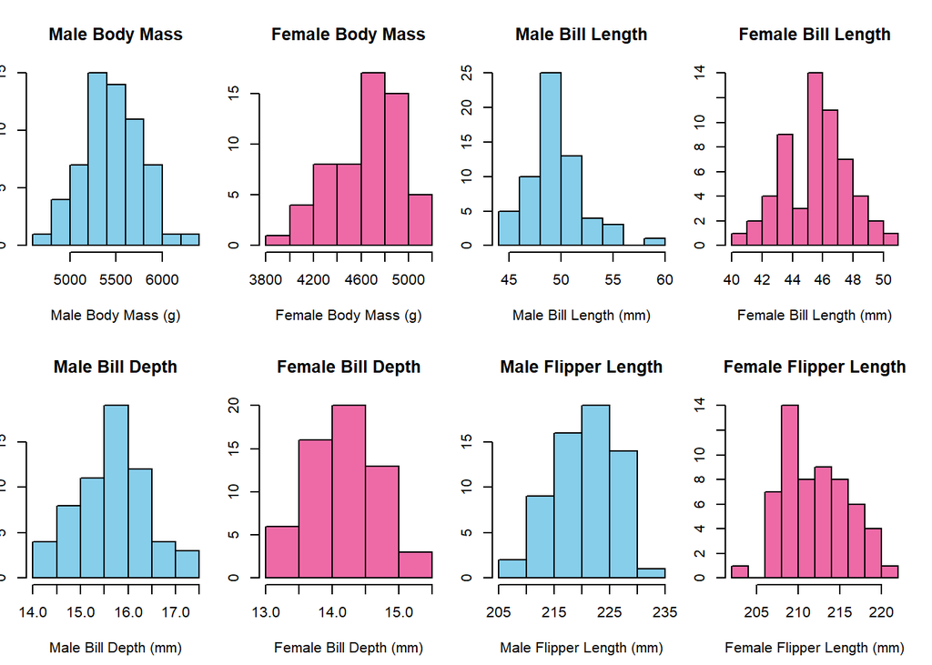

Table 4.1: Summary of Gentoo Features Data Distribution Description

|  | Male Body Mass | Female Body Mass | Male Bill Depth | Female Bill Depth | Male Bill Length | Female Bill Length | Male Flipper Length | Female Flipper Length |
| --- | --- | --- | --- | --- | --- | --- | --- | --- |
| Kurtosis | -0.30 | -0.46 | -0.3 | -0.65 | 2.05 | -0.49 | -0.72 | -0.47 |
| Skewness | 0.08 | -0.32 | 0.1 | 0.02 | 0.89 | -0.03 | -0.11 | 0.21 |

Positive values for kurtosis indicates a distribution more peaked than normal, while negative kurtosis indicates a flatter distribution. Skewness between 0.5 and -0.5 indicate symmetrical distribution, more negative values suggest stronger negative skewness, indicating longer left tail while positive skewness suggest the majority of data accumulated on the left and a longer right tail. Here, only mild skewness was observed, but most notably male bill length data demonstrated high peaked distribution (kurtosis > 2).

Shapiro-Wilk normality test was performed on body mass, bill length, bill depth and flipper length data. The p values for bill length distributions for males and females respectively were 0.01 and 0.9 respectively; and the p values for bill depth distributions for males and females were 0.4 and 0.74, respectively. The test yielded 0.99 and 0.51 for male and female body mass distributions, respectively.

For flipper length, p values were 0.05 and 0.24 for male and females, respectively. With p<0.05, null hypothesis that they come from normally distributed data is rejected. Since the data is unpaired, Mann-Whitney U test was appropriate.

## 4.2 Association of Body Weight and Sex

Table 4.2: Number of Gentoos in each weight category

|  | Female | Male |
| --- | --- | --- |
| Light | 38 | 1 |
| Medium | 20 | 21 |
| Heavy | 0 | 39 |

Since some cells in the contingency tables are <5, fisher’s exact test was appropriate to determine relation.

We conducted a Fisher’s Exact Test for Count Data to determine dependence between body mass and sex of Gentoo penguins. The results showed significant dependance, p<0.0001.

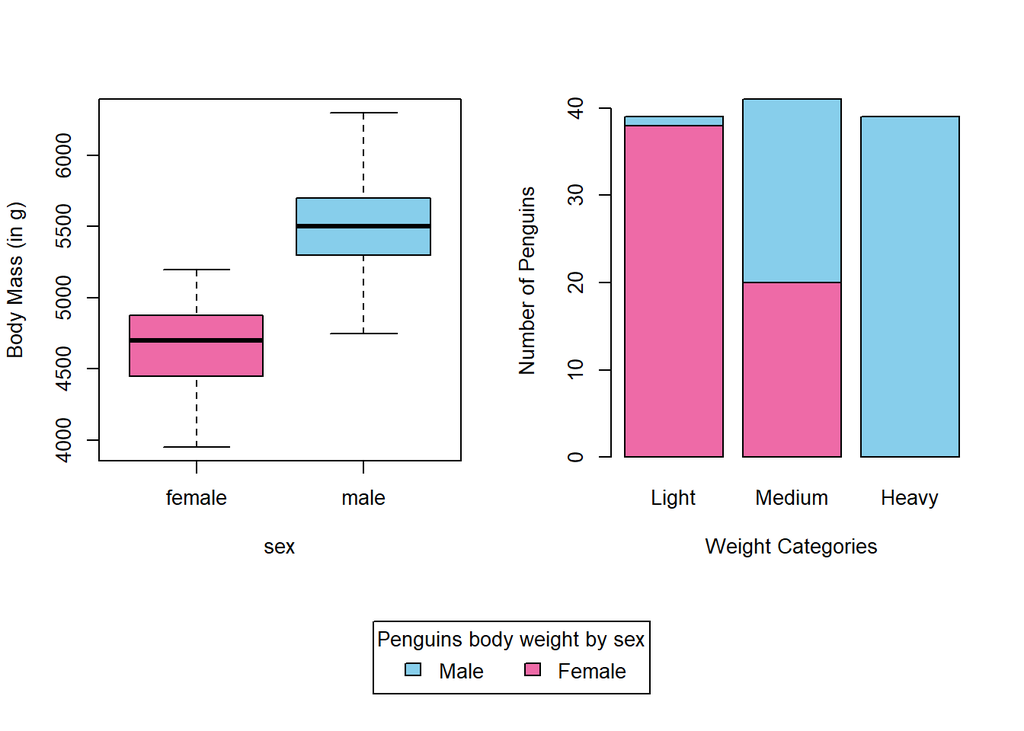

Figure 4.1: Body Mass of Males and Females

A Cramer’s V test was performed to examine the relationship between sex and body weight in Gentoo penguins and determine the effect size. There was a strong influence of the sex on body weight category distribution between all weight classes p<0.05, Cramer’s V is 0.789.

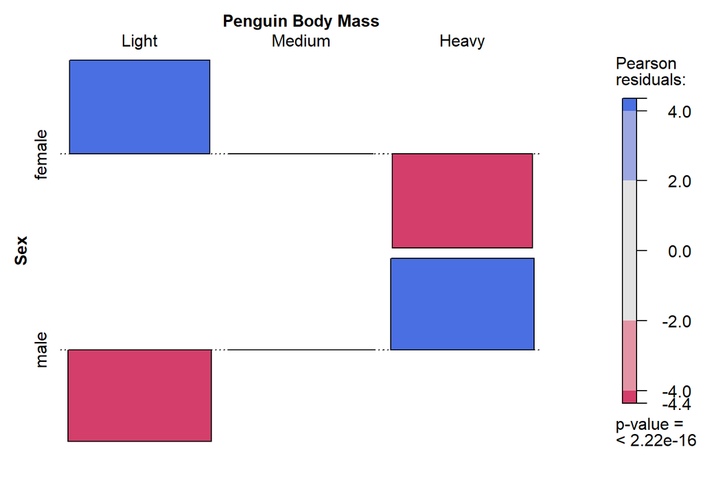

Association of the sexes with body weight categories was examined. For this, pearson residuals for six different associations could be considered among sexes and three categories. A positive association is demonstrated with a positive blue bar, and a negative association is demonstrated with a negative red bar. The intensity of the color suggests stronger association. Here, it can be seen that more females than would be expected by chance were observed in light category, while more males than by chance were observed in heavy category. There was little effect of sex on medium weight category.

## 4.3 Association of Bill Depth and Sex

Table 4.3: Number of Gentoos in each Bill Depth category

|  | Female | Male |
| --- | --- | --- |
| Shallow | 35 | 3 |
| Medium | 22 | 20 |
| Deep | 1 | 38 |

Since some cells in the contingency tables are <5, fisher’s exact test was appropriate to determine relation.

We conducted a Fisher’s Exact Test for Count Data to determine dependence between bill depth and sex of Gentoo penguins. The results showed significant dependance, p<0.0001.

A Cramer’s V test was performed to examine the relationship between sex and bill depth in Gentoo penguins and determine the effect size. There was a strong influence of the sex on bill depth category distribution between all classes p<0.05, Cramer’s V is 0.722.

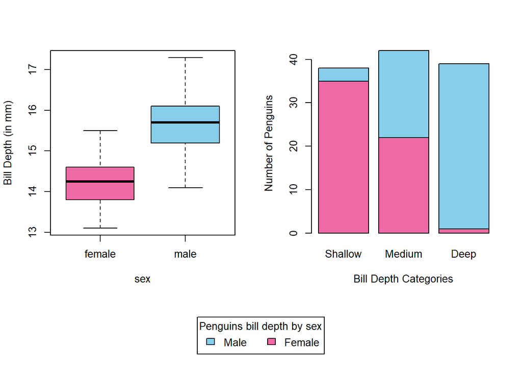

Figure 4.2: Bill Depth of Males and Females

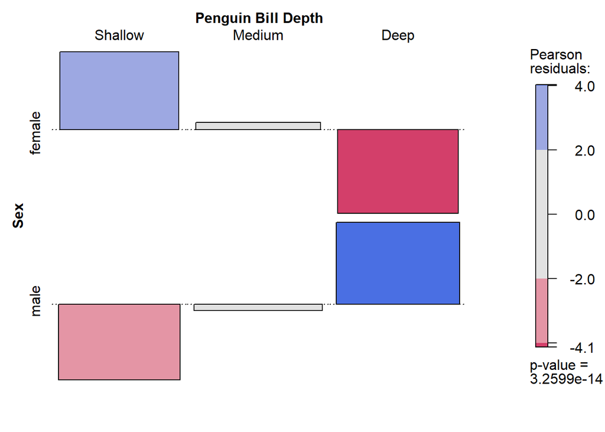

Here, it can be seen that more females than would be expected by chance had a lower bill depth. And males had higher bill depth. A strong association of sex with bill depth is observed.

## 4.4 Association of Bill Length and Sex

Table 4.4: Number of Gentoos in each Bill Length category

|  | Female | Male |
| --- | --- | --- |
| Shallow | 34 | 6 |
| Medium | 21 | 17 |
| Deep | 3 | 38 |

Since some cells in the contingency tables are <5, fisher’s exact test was appropriate to determine relation.

We conducted a Fisher’s Exact Test for Count Data to determine dependence between bill length and sex of Gentoo penguins. The results showed significant dependance, p<0.0001.

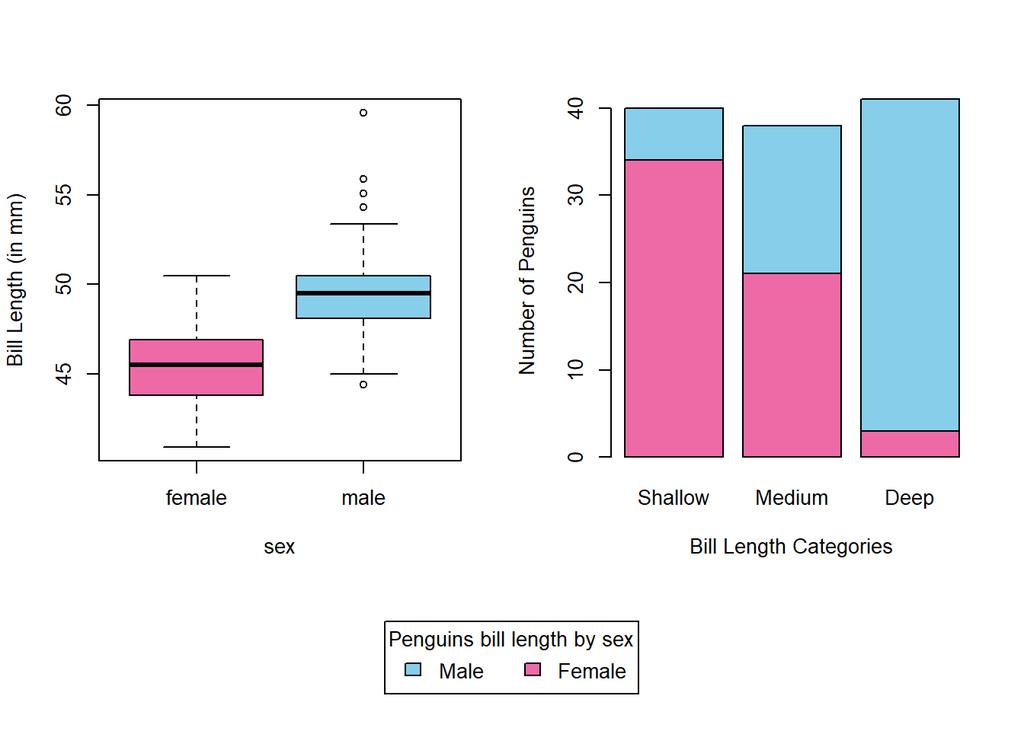

Figure 4.3: Bill Length of Males and Females

A Cramer’s V test was performed to examine the relationship between sex and bill length in Gentoo penguins and determine the effect size. There was a strong influence of the sex on bill length category distribution between all classes p<0.05, Cramer’s V is 0.647.

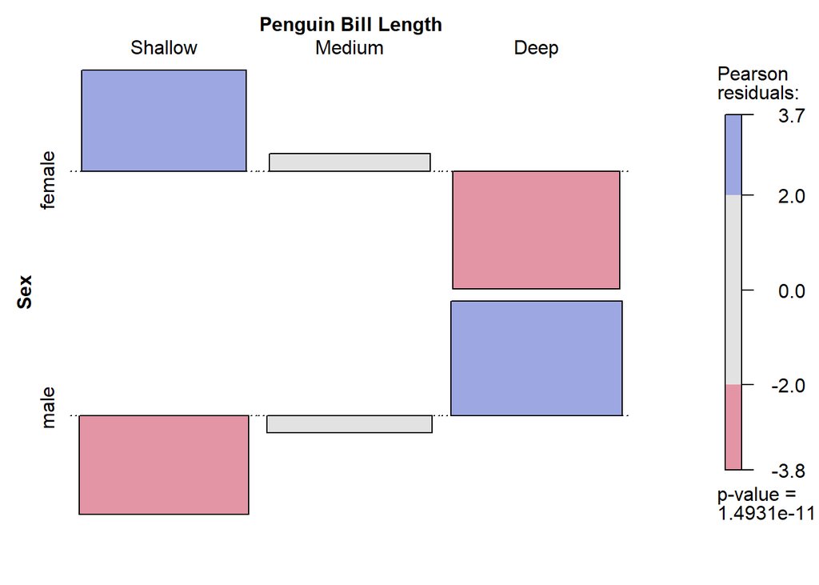

The figure demonstrated that more females than would be expected by chance had a lower bill length, while males had higher bill length. A strong association of sex with bill length was observed.

## 4.5 Flipper Length and Sex

Table 4.5: Number of Gentoos in each Flipper Length category

|  | Female | Male |
| --- | --- | --- |
| Small | 39 | 4 |
| Medium | 18 | 23 |
| Large | 1 | 34 |

Since some cells in the contingency tables are <5, fisher’s exact test was appropriate to determine relation.

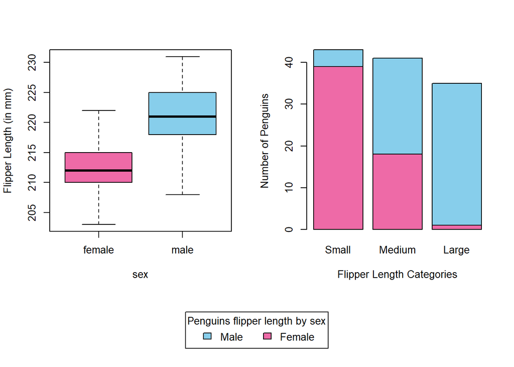

Figure 4.4: Flipper Length of Males and Females

A Cramer’s V test was performed to examine the relationship between sex and flipper length in Gentoo penguins and determine the effect size. There was a strong influence of the sex on flipper length category distribution between all flipper length classes p<0.05,Cramer’s V is 0.711.

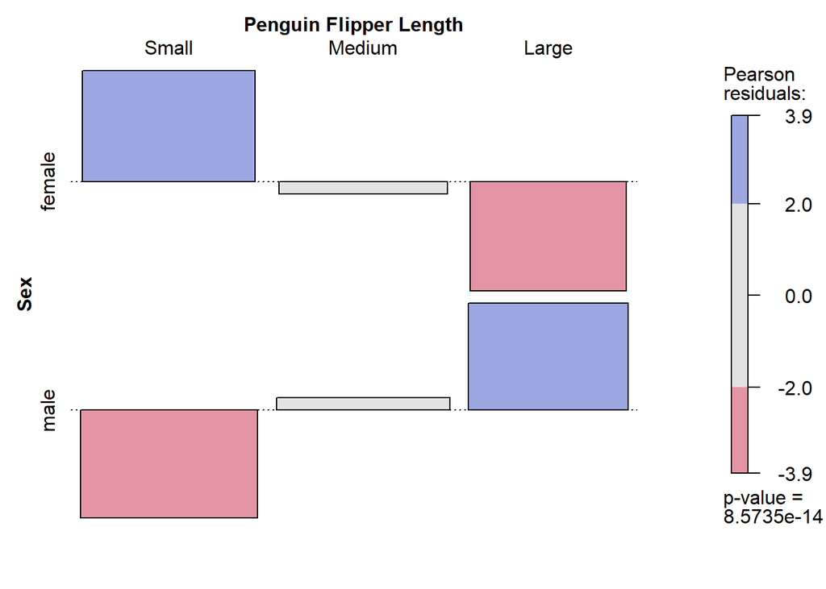

The results indicate that more females than would be expected by chance had flippers that were categorized as short, while males had longer flippers. Sex was found to be associated with flipper length.

## 4.6 Summary

Table 4.6: Association of penguin features with sex

|  | Cramer’s V Values |
| --- | --- |
| Body Mass | 0.789 |
| Bill Length | 0.647 |
| Bill Depth | 0.722 |
| Flipper Length | 0.711 |

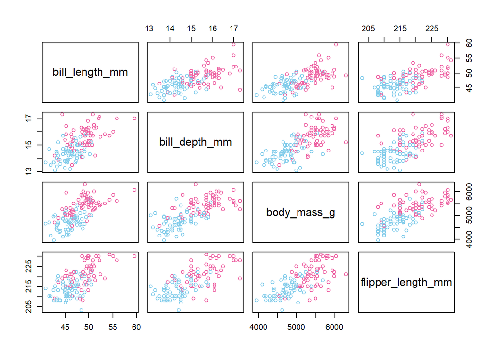

Figure 4.5: Paired up association of Gentoo features Summary

# 5 Discussion

# 6 Bibliography

Gorman, Kristen B, Tony D Williams, and William R Fraser. 2014. “Ecological Sexual Dimorphism and Environmental Variability Within a Community of Antarctic Penguins (Genus Pygoscelis).” *PLOS ONE* 9 (3).

Gorman, Tony D. AND Fraser, Kristen B. AND Williams. 2014. “Ecological Sexual Dimorphism and Environmental Variability Within a Community of Antarctic Penguins (Genus Pygoscelis).” *PLOS ONE* 9 (3): 1–14. https://doi.org/10.1371/journal.pone.0090081.

Grolemund, Garrett, and Hadley Wickham. 2011. “Dates and Times Made Easy with lubridate.” *Journal of Statistical Software* 40 (3): 1–25. https://www.jstatsoft.org/v40/i03/.

Horst, Allison M, Alison Presmanes Hill, and Kristen B Gorman. 2022. “Palmer Archipelago Penguins Data in the Palmerpenguins R Package - An Alternative to Anderson’s Irises” 14.

Horst, Allison, Alison Hill, and Kristen Gorman. 2022. *Palmerpenguins: Palmer Archipelago (Antarctica) Penguin Data*. https://allisonhorst.github.io/palmerpenguins/.

Mancini, Patrícia L., Alexander L. Bond, Keith A. Hobson, Leandro S. Duarte, and Leandro Bugoni. 2013. “Foraging Segregation in Tropical and Polar Seabirds: Testing the Intersexual Competition Hypothesis.” *Journal of Experimental Marine Biology and Ecology* 449: 186–93. https://doi.org/https://doi.org/10.1016/j.jembe.2013.09.011.

Meyer, David, Achim Zeileis, and Kurt Hornik. 2006. “The Strucplot Framework: Visualizing Multi-Way Contingency Tables with Vcd.” *Journal of Statistical Software* 17 (3): 1–48. https://doi.org/10.18637/jss.v017.i03.

Moreno, J, A Barbosa, A De Leon, and J A Fargallo. 1999. “Phenotypic Selection on Morphology at Independence in the Chinstrap Penguin Pygoscelis Antarctica.” *J. EVOL. BIOL.*

Müller, Kirill, and Hadley Wickham. 2023. *Tibble: Simple Data Frames*. https://tibble.tidyverse.org/.

Navarro, Danielle. 2021. *Lsr: Companion to "Learning Statistics with r"*. https://github.com/djnavarro/lsr.

R Core Team. 2023. *R: A Language and Environment for Statistical Computing*. Vienna, Austria: R Foundation for Statistical Computing. https://www.R-project.org/.

Ripley, Brian. 2023. *MASS: Support Functions and Datasets for Venables and Ripley’s MASS*. http://www.stats.ox.ac.uk/pub/MASS4/.

Shaffer, S. A., H. Weimerskirch, and D. P. Costa. 2001. “Functional Significance of Sexual Dimorphism in Wandering Albatrosses, Diomedea Exulans.” *Functional Ecology* 15 (2): 203–10. https://doi.org/https://doi.org/10.1046/j.1365-2435.2001.00514.x.

Spinu, Vitalie, Garrett Grolemund, and Hadley Wickham. 2023. *Lubridate: Make Dealing with Dates a Little Easier*. https://lubridate.tidyverse.org.

Venables, W. N., and B. D. Ripley. 2002. *Modern Applied Statistics with s*. Fourth. New York: Springer. https://www.stats.ox.ac.uk/pub/MASS4/.

Wickham, Hadley. 2016. *Ggplot2: Elegant Graphics for Data Analysis*. Springer-Verlag New York. https://ggplot2.tidyverse.org.

———. 2022. *Stringr: Simple, Consistent Wrappers for Common String Operations*. https://stringr.tidyverse.org.

———. 2023a. *Forcats: Tools for Working with Categorical Variables (Factors)*. https://forcats.tidyverse.org/.

———. 2023b. *Tidyverse: Easily Install and Load the Tidyverse*. https://tidyverse.tidyverse.org.

Wickham, Hadley, Mara Averick, Jennifer Bryan, Winston Chang, Lucy D’Agostino McGowan, Romain François, Garrett Grolemund, et al. 2019. “Welcome to the tidyverse.” *Journal of Open Source Software* 4 (43): 1686. https://doi.org/10.21105/joss.01686.

Wickham, Hadley, Winston Chang, Lionel Henry, Thomas Lin Pedersen, Kohske Takahashi, Claus Wilke, Kara Woo, Hiroaki Yutani, and Dewey Dunnington. 2023. *Ggplot2: Create Elegant Data Visualisations Using the Grammar of Graphics*. https://ggplot2.tidyverse.org.

Wickham, Hadley, Romain François, Lionel Henry, Kirill Müller, and Davis Vaughan. 2023. *Dplyr: A Grammar of Data Manipulation*. https://dplyr.tidyverse.org.

Wickham, Hadley, and Lionel Henry. 2023. *Purrr: Functional Programming Tools*. https://purrr.tidyverse.org/.

Wickham, Hadley, Jim Hester, and Jennifer Bryan. 2023. *Readr: Read Rectangular Text Data*. https://readr.tidyverse.org.

Wickham, Hadley, Davis Vaughan, and Maximilian Girlich. 2023. *Tidyr: Tidy Messy Data*. https://tidyr.tidyverse.org.

WILLIAMS, T. D. 1991. “Foraging Ecology and Diet of Gentoo Penguins Pygoscelis Papua at South Georgia During Winter and an Assessment of Their Winter Prey Consumption.” *Ibis* 133 (1): 3–13. https://doi.org/https://doi.org/10.1111/j.1474-919X.1991.tb04803.x.

Xie, Yihui. 2014. “Knitr: A Comprehensive Tool for Reproducible Research in R.” In *Implementing Reproducible Computational Research*, edited by Victoria Stodden, Friedrich Leisch, and Roger D. Peng. Chapman; Hall/CRC.

———. 2015. *Dynamic Documents with R and Knitr*. 2nd ed. Boca Raton, Florida: Chapman; Hall/CRC. https://yihui.org/knitr/.

———. 2016. *Bookdown: Authoring Books and Technical Documents with R Markdown*. Boca Raton, Florida: Chapman; Hall/CRC. https://bookdown.org/yihui/bookdown.

———. 2023a. *Bookdown: Authoring Books and Technical Documents with r Markdown*. https://github.com/rstudio/bookdown.

———. 2023b. *Knitr: A General-Purpose Package for Dynamic Report Generation in r*. https://yihui.org/knitr/.

Zeileis, Achim, David Meyer, and Kurt Hornik. 2007. “Residual-Based Shadings for Visualizing (Conditional) Independence.” *Journal of Computational and Graphical Statistics* 16 (3): 507–25. https://doi.org/10.1198/106186007X237856.